# Prescriptive Analytics: Employee Retention Planning

From attrition risk to budget-constrained action

Analytics Solutions Bootcamp

07 September 2026

```r
knitr::opts_chunk$set(
  echo = TRUE,
  message = FALSE,
  warning = FALSE,
  fig.width = 9,
  fig.height = 5
)

required_packages <- c(
  "modeldata", "tidyverse", "janitor", "rsample",
  "recipes", "lpSolve", "scales", "broom"
)

missing_packages <- required_packages[
  !required_packages %in% rownames(installed.packages())
]

if (length(missing_packages) > 0) {
  stop(
    "Install the missing packages first: ",
    paste(missing_packages, collapse = ", ")
  )
}

library(modeldata)
library(tidyverse)
library(janitor)
library(rsample)
library(recipes)
library(lpSolve)
library(scales)
library(broom)

set.seed(123)
```

# 1 Lab scenario

An organization has a limited annual budget for employee-retention programs. HR cannot offer every intervention to every employee group, so management must decide which programs to fund and where to deploy them.

This lab extends attrition classification into **prescriptive analytics**:

- Predictive question: Who may be at risk of leaving?
- Prescriptive question: What should HR do with that information?

The objective is to maximize the expected financial benefit of retention initiatives while respecting the available budget and HR’s implementation capacity.

> **Responsible-use boundary:** The dataset is synthetic and the intervention costs and effects in this lab are assumptions. Recommendations are made for employee segments, not as an employee-level watchlist. A real program requires privacy review, fairness testing, voluntary and supportive interventions, causal evidence, and human oversight. Never use attrition scores for dismissal, promotion denial, surveillance, or other punitive decisions.

## 1.1 Operational questions

1. Which workforce segments have the greatest expected turnover exposure?
2. Which retention intervention offers the highest expected monetary value for each segment?
3. Given a fixed budget, which segment–intervention combinations should HR fund?
4. How much expected turnover cost could the recommended portfolio avoid?
5. How does the recommendation change when the budget or intervention effectiveness changes?
6. Which assumptions are most important to validate before implementation?

# 2 1. Frame the decision problem

Following the components of a decision problem:

| Component | Definition in this lab |
| --- | --- |
| Objective | Maximize expected net benefit from retention programs |
| Alternatives | No action, flexible work, career development, training, or compensation review |
| Constraints | Annual budget and maximum number of programs HR can implement |
| Uncertainty | Whether employees would leave and whether an intervention would prevent attrition |
| Decision unit | One intervention for an employee segment |

This is a **decision under risk** because probabilities can be estimated, but the outcomes are not certain.

# 3 2. Load and inspect the data

```r
data(attrition, package = "modeldata")

attrition_data <- attrition |>
  clean_names() |>
  mutate(attrition = factor(attrition, levels = c("No", "Yes")))

glimpse(attrition_data)
```

```
## Rows: 1,470
## Columns: 31
## $ age                        <int> 41, 49, 37, 33, 27, 32, 59, 30, 38, 36, 35,…
## $ attrition                  <fct> Yes, No, Yes, No, No, No, No, No, No, No, N…
## $ business_travel            <fct> Travel_Rarely, Travel_Frequently, Travel_Ra…
## $ daily_rate                 <int> 1102, 279, 1373, 1392, 591, 1005, 1324, 135…
## $ department                 <fct> Sales, Research_Development, Research_Devel…
## $ distance_from_home         <int> 1, 8, 2, 3, 2, 2, 3, 24, 23, 27, 16, 15, 26…
## $ education                  <ord> College, Below_College, College, Master, Be…
## $ education_field            <fct> Life_Sciences, Life_Sciences, Other, Life_S…
## $ environment_satisfaction   <ord> Medium, High, Very_High, Very_High, Low, Ve…
## $ gender                     <fct> Female, Male, Male, Female, Male, Male, Fem…
## $ hourly_rate                <int> 94, 61, 92, 56, 40, 79, 81, 67, 44, 94, 84,…
## $ job_involvement            <ord> High, Medium, Medium, High, High, High, Ver…
## $ job_level                  <int> 2, 2, 1, 1, 1, 1, 1, 1, 3, 2, 1, 2, 1, 1, 1…
```

[output cut: 18 more lines]

```r
tibble(
  employees = nrow(attrition_data),
  variables = ncol(attrition_data),
  duplicate_rows = sum(duplicated(attrition_data)),
  missing_values = sum(is.na(attrition_data)),
  observed_attrition_rate = mean(attrition_data$attrition == "Yes")
)
```

```
## # A tibble: 1 × 5
##   employees variables duplicate_rows missing_values observed_attrition_rate
##       <int>     <int>          <int>          <int>                   <dbl>
## 1      1470        31              0              0                   0.161
```

```r
attrition_data |>
  group_by(job_role, over_time) |>
  summarise(
    employees = n(),
    employees_who_left = sum(attrition == "Yes"),
    historical_attrition_rate = mean(attrition == "Yes"),
    median_monthly_income = median(monthly_income),
    .groups = "drop"
  ) |>
  arrange(desc(historical_attrition_rate))
```

```
## # A tibble: 18 × 6
##    job_role        over_time employees employees_who_left historical_attrition…¹
##    <fct>           <fct>         <int>              <int>                  <dbl>
##  1 Sales_Represen… Yes              24                 16                 0.667
##  2 Laboratory_Tec… Yes              62                 31                 0.5
##  3 Human_Resources Yes              13                  5                 0.385
##  4 Research_Scien… Yes              97                 33                 0.340
##  5 Sales_Executive Yes              94                 31                 0.330
##  6 Sales_Represen… No               59                 17                 0.288
##  7 Human_Resources No               39                  7                 0.179
##  8 Laboratory_Tec… No              197                 31                 0.157
##  9 Manager         Yes              27                  4                 0.148
## 10 Sales_Executive No              232                 26                 0.112
## 11 Manufacturing_… Yes              39                  4                 0.103
## 12 Healthcare_Rep… No               94                  7                 0.0745
## 13 Research_Scien… No              195                 14                 0.0718
## 14 Manufacturing_… No              106                  6                 0.0566
## 15 Healthcare_Rep… Yes              37                  2                 0.0541
## 16 Research_Direc… Yes              23                  1                 0.0435
## 17 Research_Direc… No               57                  1                 0.0175
## 18 Manager         No               75                  1                 0.0133
## # ℹ abbreviated name: ¹historical_attrition_rate
## # ℹ 1 more variable: median_monthly_income <dbl>
```

# 4 3. Estimate attrition probabilities

The classification model is an input to the decision—not the final output. We create a stratified training/test split and treat the test set as a simulated future planning population whose outcomes are not used to make decisions.

```r
attrition_split <- initial_split(
  attrition_data,
  prop = 0.80,
  strata = attrition
)

training_data <- training(attrition_split)
planning_data <- testing(attrition_split)

tibble(
  dataset = c("Training data", "Planning population"),
  employees = c(nrow(training_data), nrow(planning_data)),
  attrition_rate = c(
    mean(training_data$attrition == "Yes"),
    mean(planning_data$attrition == "Yes")
  )
)
```

```
## # A tibble: 2 × 3
##   dataset             employees attrition_rate
##   <chr>                   <int>          <dbl>
## 1 Training data            1175          0.161
## 2 Planning population       295          0.163
```

```r
excluded_variables <- c(
  "employee_number",
  "employee_count",
  "over18",
  "standard_hours",
  "gender"
)

attrition_recipe <- recipe(attrition ~ ., data = training_data) |>
  # step_rm(all_of(excluded_variables)) |>
  step_novel(all_nominal_predictors()) |>
  step_unknown(all_nominal_predictors()) |>
  step_dummy(all_nominal_predictors()) |>
  step_zv(all_predictors())

prepared_recipe <- prep(attrition_recipe, training = training_data)

training_baked <- bake(prepared_recipe, new_data = NULL)
planning_baked <- bake(prepared_recipe, new_data = planning_data)
```

```r
risk_model <- glm(
  attrition ~ .,
  data = training_baked,
  family = binomial()
)

planning_scored <- planning_data |>
  mutate(
    predicted_attrition_probability = predict(
      risk_model,
      newdata = planning_baked,
      type = "response"
    )
  )

summary(planning_scored$predicted_attrition_probability)
```

```
##    Min. 1st Qu.  Median    Mean 3rd Qu.    Max.
## 0.00000 0.01577 0.06828 0.17287 0.22159 0.97196
```

The predicted probability is an estimate—not a fact and not a causal explanation. It should be recalibrated and monitored when used on a genuinely future population.

# 5 4. Translate risk into expected turnover exposure

For demonstration, assume that replacing an employee costs approximately six months of the employee’s monthly income. This includes recruiting, onboarding, vacancy, and productivity costs. In practice, Finance and HR should estimate this value by role and validate it using organizational data.

For employee $i$:

$$\text{Expected turnover exposure}_i =
P(\text{attrition}_i) \times \text{estimated turnover cost}_i$$

```r
replacement_months <- 6

planning_scored <- planning_scored |>
  mutate(
    estimated_turnover_cost = monthly_income * replacement_months,
    expected_turnover_exposure =
      predicted_attrition_probability * estimated_turnover_cost
  )

planning_scored |>
  summarise(
    employees = n(),
    mean_predicted_risk = mean(predicted_attrition_probability),
    estimated_total_turnover_cost = sum(estimated_turnover_cost),
    expected_turnover_exposure = sum(expected_turnover_exposure)
  )
```

```
##   employees mean_predicted_risk estimated_total_turnover_cost
## 1       295           0.1728671                      11583270
##   expected_turnover_exposure
## 1                    1571314
```

## 5.1 Aggregate to decision segments

The lab uses `job_role` and `over_time` to form operationally understandable segments. Very small groups should be combined or suppressed in production to reduce privacy and statistical-stability risks.

```r
segment_summary <- planning_scored |>
  group_by(job_role, over_time) |>
  summarise(
    employees = n(),
    mean_predicted_risk = mean(predicted_attrition_probability),
    expected_attrition_cases = sum(predicted_attrition_probability),
    total_expected_exposure = sum(expected_turnover_exposure),
    .groups = "drop"
  ) |>
  mutate(
    segment_id = row_number(),
    segment = paste(job_role, paste0("Overtime: ", over_time), sep = " | ")
  )

segment_summary |>
  arrange(desc(total_expected_exposure))
```

```
## # A tibble: 18 × 8
##    job_role       over_time employees mean_predicted_risk expected_attrition_c…¹
##    <fct>          <fct>         <int>               <dbl>                  <dbl>
##  1 Sales_Executi… No               48              0.170                   8.15
##  2 Sales_Executi… Yes              17              0.343                   5.83
##  3 Research_Scie… Yes              20              0.319                   6.38
##  4 Laboratory_Te… No               37              0.165                   6.10
##  5 Laboratory_Te… Yes              11              0.458                   5.04
##  6 Sales_Represe… No               17              0.324                   5.52
##  7 Manufacturing… Yes               9              0.187                   1.68
##  8 Research_Scie… No               43              0.108                   4.65
##  9 Healthcare_Re… Yes               9              0.188                   1.69
## 10 Research_Dire… Yes               4              0.166                   0.666
## 11 Healthcare_Re… No               18              0.0518                  0.932
## 12 Manager        Yes               6              0.0502                  0.301
## 13 Sales_Represe… Yes               3              0.550                   1.65
## 14 Manufacturing… No               19              0.0341                  0.648
## 15 Manager        No               19              0.0128                  0.244
## 16 Human_Resourc… No                4              0.212                   0.847
## 17 Research_Dire… No                9              0.0189                  0.170
## 18 Human_Resourc… Yes               2              0.249                   0.499
## # ℹ abbreviated name: ¹expected_attrition_cases
## # ℹ 3 more variables: total_expected_exposure <dbl>, segment_id <int>,
## #   segment <chr>
```

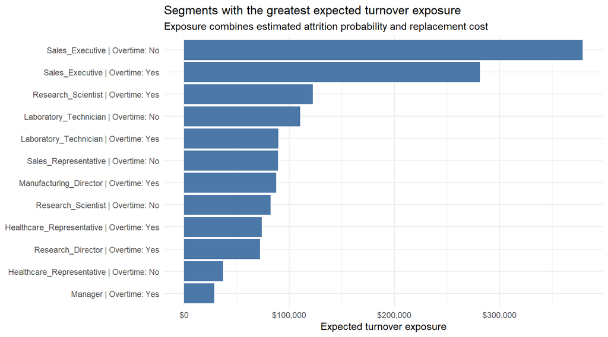

```r
segment_summary |>
  slice_max(total_expected_exposure, n = 12) |>
  ggplot(aes(
    x = reorder(segment, total_expected_exposure),
    y = total_expected_exposure
  )) +
  geom_col(fill = "#4C78A8") +
  coord_flip() +
  scale_y_continuous(labels = dollar) +
  labs(
    title = "Segments with the greatest expected turnover exposure",
    subtitle = "Exposure combines estimated attrition probability and replacement cost",
    x = NULL,
    y = "Expected turnover exposure"
  ) +
  theme_minimal()
```

# 6 5. Define intervention alternatives

The following values are hypothetical scenario assumptions. `effectiveness` represents the assumed relative reduction in attrition risk among participating employees.

```r
interventions <- tribble(
  ~intervention,          ~cost_per_employee, ~effectiveness,
  "Flexible work",                       500,           0.10,
  "Career development",                 1500,           0.22,
  "Training program",                   1200,           0.18,
  "Compensation review",                2500,           0.30
)

interventions
```

```
## # A tibble: 4 × 3
##   intervention        cost_per_employee effectiveness
##   <chr>                           <dbl>         <dbl>
## 1 Flexible work                     500          0.1
## 2 Career development               1500          0.22
## 3 Training program                 1200          0.18
## 4 Compensation review              2500          0.3
```

## 6.1 Expected monetary value

For segment $s$ and intervention $j$:

$$\text{Expected avoided cost}_{sj} =
\text{Expected exposure}_{s} \times \text{Effectiveness}_{j}$$

$$\text{Expected net benefit}_{sj} =
\text{Expected avoided cost}_{sj} - \text{Program cost}_{sj}$$

```r
decision_options <- crossing(
  segment_summary,
  interventions
) |>
  mutate(
    option_id = row_number(),
    program_cost = employees * cost_per_employee,
    expected_avoided_cost = total_expected_exposure * effectiveness,
    expected_net_benefit = expected_avoided_cost - program_cost,
    expected_roi = expected_net_benefit / program_cost
  )

decision_options |>
  arrange(desc(expected_net_benefit)) |>
  select(
    segment, intervention, employees, program_cost,
    expected_avoided_cost, expected_net_benefit, expected_roi
  ) |>
  slice_head(n = 15)
```

```
## # A tibble: 15 × 7
##    segment             intervention employees program_cost expected_avoided_cost
##    <chr>               <chr>            <int>        <dbl>                 <dbl>
##  1 Sales_Executive | … Compensatio…        17        42500                84454.
##  2 Sales_Executive | … Career deve…        17        25500                61933.
##  3 Sales_Executive | … Training pr…        17        20400                50672.
##  4 Sales_Executive | … Flexible wo…        17         8500                28151.
##  5 Sales_Executive | … Flexible wo…        48        24000                37921.
##  6 Research_Director … Compensatio…         4        10000                21695.
##  7 Sales_Executive | … Career deve…        48        72000                83426.
##  8 Sales_Executive | … Training pr…        48        57600                68258.
##  9 Research_Director … Career deve…         4         6000                15910.
## 10 Research_Director … Training pr…         4         4800                13017.
## 11 Manufacturing_Dire… Career deve…         9        13500                19280.
## 12 Research_Director … Flexible wo…         4         2000                 7232.
## 13 Manufacturing_Dire… Training pr…         9        10800                15775.
## 14 Manufacturing_Dire… Flexible wo…         9         4500                 8764.
## 15 Manufacturing_Dire… Compensatio…         9        22500                26291.
## # ℹ 2 more variables: expected_net_benefit <dbl>, expected_roi <dbl>
```

Negative expected net benefit means that the intervention costs more than its estimated avoided turnover cost under the current assumptions. “No action” is implicitly available because the optimizer is not required to select an option for every segment.

# 7 6. Optimize the retention portfolio

Suppose HR has:

- an annual budget of $150,000; and
- capacity to implement programs in at most six employee segments.

The decision variable $x_{sj}$ is binary:

- $x_{sj}=1$: fund intervention $j$ for segment $s$;
- $x_{sj}=0$: do not fund it.

The model maximizes total expected net benefit subject to:

1. Total program cost cannot exceed the budget.
2. At most one intervention may be selected for each segment.
3. At most six segment-level programs may be implemented.

```r
annual_budget <- 150000
maximum_programs <- 6

number_of_options <- nrow(decision_options)
number_of_segments <- nrow(segment_summary)

budget_constraint <- decision_options$program_cost

segment_constraints <- outer(
  segment_summary$segment_id,
  decision_options$segment_id,
  FUN = function(segment, option_segment) {
    as.numeric(segment == option_segment)
  }
)

program_count_constraint <- rep(1, number_of_options)

constraint_matrix <- rbind(
  budget_constraint,
  segment_constraints,
  program_count_constraint
)

constraint_directions <- c(
  "<=",
  rep("<=", number_of_segments),
  "<="
)

constraint_limits <- c(
  annual_budget,
  rep(1, number_of_segments),
  maximum_programs
)
```

```r
optimization_result <- lp(
  direction = "max",
  objective.in = decision_options$expected_net_benefit,
  const.mat = constraint_matrix,
  const.dir = constraint_directions,
  const.rhs = constraint_limits,
  all.bin = TRUE
)

if (optimization_result$status != 0) {
  stop("The optimization model did not find an optimal solution.")
}

recommended_portfolio <- decision_options |>
  mutate(selected = optimization_result$solution > 0.5) |>
  filter(selected) |>
  arrange(desc(expected_net_benefit))

recommended_portfolio |>
  select(
    segment, intervention, employees, mean_predicted_risk,
    program_cost, expected_avoided_cost,
    expected_net_benefit, expected_roi
  )
```

```
## # A tibble: 6 × 8
##   segment                intervention employees mean_predicted_risk program_cost
##   <chr>                  <chr>            <int>               <dbl>        <dbl>
## 1 Sales_Executive | Ove… Compensatio…        17               0.343        42500
## 2 Sales_Executive | Ove… Flexible wo…        48               0.170        24000
## 3 Research_Director | O… Compensatio…         4               0.166        10000
## 4 Manufacturing_Directo… Career deve…         9               0.187        13500
## 5 Laboratory_Technician… Flexible wo…        11               0.458         5500
## 6 Healthcare_Representa… Flexible wo…         9               0.188         4500
## # ℹ 3 more variables: expected_avoided_cost <dbl>, expected_net_benefit <dbl>,
## #   expected_roi <dbl>
```

```r
portfolio_summary <- recommended_portfolio |>
  summarise(
    selected_programs = n(),
    employees_covered = sum(employees),
    total_program_cost = sum(program_cost),
    unused_budget = annual_budget - total_program_cost,
    expected_avoided_cost = sum(expected_avoided_cost),
    expected_net_benefit = sum(expected_net_benefit),
    portfolio_roi = expected_net_benefit / total_program_cost
  )

portfolio_summary
```

```
## # A tibble: 1 × 7
##   selected_programs employees_covered total_program_cost unused_budget
##               <int>             <int>              <dbl>         <dbl>
## 1                 6                98             100000         50000
## # ℹ 3 more variables: expected_avoided_cost <dbl>, expected_net_benefit <dbl>,
## #   portfolio_roi <dbl>
```

## 7.1 Compare with a simple ranking rule

A common heuristic is to fund options from highest to lowest predicted risk. That approach ignores differences in employee count, turnover cost, program cost, and intervention effectiveness. The optimized recommendation explicitly balances these trade-offs.

```r
risk_priority <- decision_options |>
  group_by(segment_id) |>
  slice_max(effectiveness, n = 1, with_ties = FALSE) |>
  ungroup() |>
  arrange(desc(mean_predicted_risk)) |>
  mutate(
    cumulative_cost = cumsum(program_cost),
    rank = row_number()
  ) |>
  filter(
    cumulative_cost <= annual_budget,
    rank <= maximum_programs
  )

bind_rows(
  recommended_portfolio |>
    summarise(
      approach = "Optimized portfolio",
      programs = n(),
      cost = sum(program_cost),
      expected_avoided_cost = sum(expected_avoided_cost),
      expected_net_benefit = sum(expected_net_benefit)
    ),
  risk_priority |>
    summarise(
      approach = "Highest-risk-first heuristic",
      programs = n(),
      cost = sum(program_cost),
      expected_avoided_cost = sum(expected_avoided_cost),
      expected_net_benefit = sum(expected_net_benefit)
    )
)
```

```
## # A tibble: 2 × 5
##   approach            programs   cost expected_avoided_cost expected_net_benefit
##   <chr>                  <int>  <dbl>                 <dbl>                <dbl>
## 1 Optimized portfolio        6 100000               179723.               79723.
## 2 Highest-risk-first…        4 120000               145881.               25881.
```

# 8 7. Budget scenario analysis

Optimization is most useful when decision makers can ask, “What changes if the constraint changes?” The function below resolves the portfolio for different budget levels.

```r
optimize_portfolio <- function(options, budget, max_programs = 6) {
  n_options <- nrow(options)
  segment_ids <- sort(unique(options$segment_id))

  segment_matrix <- outer(
  segment_ids,
  options$segment_id,
  FUN = function(segment, option_segment) {
    as.numeric(segment == option_segment)
  }
)

  constraint_matrix <- rbind(
    options$program_cost,
    segment_matrix,
    rep(1, n_options)
  )

  result <- lp(
    direction = "max",
    objective.in = options$expected_net_benefit,
    const.mat = constraint_matrix,
    const.dir = c("<=", rep("<=", length(segment_ids)), "<="),
    const.rhs = c(budget, rep(1, length(segment_ids)), max_programs),
    all.bin = TRUE
  )

  if (result$status != 0) {
    return(tibble(
      budget = budget,
      selected_programs = NA_integer_,
      total_cost = NA_real_,
      expected_avoided_cost = NA_real_,
      expected_net_benefit = NA_real_
    ))
  }

  selected <- options[result$solution > 0.5, ]

  tibble(
    budget = budget,
    selected_programs = nrow(selected),
    total_cost = sum(selected$program_cost),
    expected_avoided_cost = sum(selected$expected_avoided_cost),
    expected_net_benefit = sum(selected$expected_net_benefit)
  )
}
```

```r
budget_results <- map_dfr(
  seq(50000, 300000, by = 25000),
  ~ optimize_portfolio(decision_options, budget = .x)
)

budget_results
```

```
## # A tibble: 11 × 5
##    budget selected_programs total_cost expected_avoided_cost
##     <dbl>             <int>      <dbl>                 <dbl>
##  1  50000                 5      50000               108764.
##  2  75000                 6      74000               146685.
##  3 100000                 6     100000               179723.
##  4 125000                 6     100000               179723.
##  5 150000                 6     100000               179723.
##  6 175000                 6     100000               179723.
##  7 200000                 6     100000               179723.
##  8 225000                 6     100000               179723.
##  9 250000                 6     100000               179723.
## 10 275000                 6     100000               179723.
## 11 300000                 6     100000               179723.
## # ℹ 1 more variable: expected_net_benefit <dbl>
```

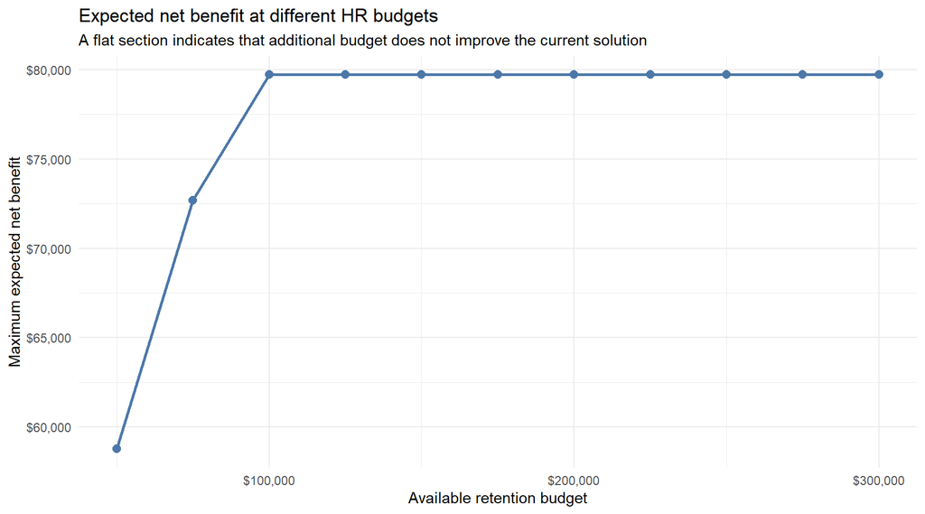

```r
budget_results |>
  ggplot(aes(budget, expected_net_benefit)) +
  geom_line(color = "#4C78A8", linewidth = 1) +
  geom_point(color = "#4C78A8", size = 2.5) +
  scale_x_continuous(labels = dollar) +
  scale_y_continuous(labels = dollar) +
  labs(
    title = "Expected net benefit at different HR budgets",
    subtitle = "A flat section indicates that additional budget does not improve the current solution",
    x = "Available retention budget",
    y = "Maximum expected net benefit"
  ) +
  theme_minimal()
```

# 9 8. Effectiveness sensitivity analysis

Intervention effectiveness is uncertain. Test pessimistic, base, and optimistic assumptions by applying a multiplier to every intervention’s effectiveness.

```r
effectiveness_scenarios <- tribble(
  ~scenario,      ~effectiveness_multiplier,
  "Pessimistic",                      0.60,
  "Base",                             1.00,
  "Optimistic",                       1.30
)

effectiveness_results <- effectiveness_scenarios |>
  mutate(
    options = map(effectiveness_multiplier, function(multiplier) {
      decision_options |>
        mutate(
          scenario_effectiveness = pmin(effectiveness * multiplier, 1),
          expected_avoided_cost =
            total_expected_exposure * scenario_effectiveness,
          expected_net_benefit = expected_avoided_cost - program_cost
        )
    }),
    result = map(
      options,
      ~ optimize_portfolio(
        .x,
        budget = annual_budget,
        max_programs = maximum_programs
      )
    )
  ) |>
  select(scenario, effectiveness_multiplier, result) |>
  unnest(result)

effectiveness_results
```

```
## # A tibble: 3 × 7
##   scenario    effectiveness_multiplier budget selected_programs total_cost
##   <chr>                          <dbl>  <dbl>             <int>      <dbl>
## 1 Pessimistic                      0.6 150000                 4      37500
## 2 Base                             1   150000                 6     100000
## 3 Optimistic                       1.3 150000                 6     148000
## # ℹ 2 more variables: expected_avoided_cost <dbl>, expected_net_benefit <dbl>
```

## 9.1 Interpretation questions

- Does the recommended portfolio remain valuable under pessimistic assumptions?
- Which recommendation changes first when effectiveness declines?
- At what budget level do expected benefits begin to flatten?
- Is unused budget evidence of an error, or are no additional options valuable under the model assumptions?
- Which assumptions should HR test through a small pilot before scaling?

# 10 9. Fairness, privacy, and governance checks

Optimization can make a mathematically efficient recommendation that is still unfair, infeasible, or harmful. Review the selected segments before acting.

```r
governance_review <- recommended_portfolio |>
  transmute(
    segment,
    intervention,
    employees,
    mean_predicted_risk,
    expected_net_benefit,
    review_small_group = employees < 10,
    review_high_risk_label = mean_predicted_risk >= 0.50
  )

governance_review
```

```
## # A tibble: 6 × 7
##   segment        intervention employees mean_predicted_risk expected_net_benefit
##   <chr>          <chr>            <int>               <dbl>                <dbl>
## 1 Sales_Executi… Compensatio…        17               0.343               41954.
## 2 Sales_Executi… Flexible wo…        48               0.170               13921.
## 3 Research_Dire… Compensatio…         4               0.166               11695.
## 4 Manufacturing… Career deve…         9               0.187                5780.
## 5 Laboratory_Te… Flexible wo…        11               0.458                3481.
## 6 Healthcare_Re… Flexible wo…         9               0.188                2892.
## # ℹ 2 more variables: review_small_group <lgl>, review_high_risk_label <lgl>
```

Required controls for a real deployment include:

1. **Data minimization:** Use only information necessary for supportive action.
2. **Access control:** Restrict employee-level data and model outputs.
3. **Fairness audit:** Examine whether error rates and benefits differ across protected groups, even when protected attributes are excluded as predictors.
4. **Causal validation:** Do not assume observational associations prove that an intervention will reduce attrition.
5. **Human review:** Managers and HR should assess feasibility and employee welfare before implementation.
6. **Voluntary participation:** Retention programs should benefit employees and avoid coercion or stigma.
7. **Monitoring:** Compare projected and realized costs, participation, employee outcomes, and attrition after deployment.

# 11 10. Recommended operational workflow

1. Validate the attrition model on recent, representative data.
2. Estimate actual turnover costs with Finance and operating teams.
3. Estimate intervention effects using historical evaluations or a pilot.
4. Define budget, capacity, policy, and fairness constraints with stakeholders.
5. Generate the optimized portfolio.
6. Conduct human, privacy, fairness, and feasibility reviews.
7. Pilot the intervention with employee consent.
8. Measure outcomes and update the assumptions before scaling.

# 12 11. Conclusions

Complete these statements after running the lab:

- The planning population contains 295 employees across 18 segments.
- Under a budget of $150,000, the optimization selects 6 segment-level programs.
- The recommended portfolio costs $100,000 and has an expected net benefit of $79,722.52.
- These are model-based expectations, not guaranteed savings.
- The recommendation is valid only to the extent that the risk, turnover-cost, and intervention-effect assumptions are credible.

# 13 12. Learner exercises

1. Change the annual budget to $75,000 and $250,000. Which recommendations change, and why?
2. Add a constraint that at least one non-overtime segment must receive a program. Explain the business justification and trade-off.
3. Allow no more than two compensation-review programs. How does this affect expected net benefit?
4. Replace six months of income with three, nine, and twelve months when estimating turnover cost. Compare the solutions.
5. Create an intervention designed specifically for overtime-related workload. Define a defensible cost and effectiveness range.
6. Compare the optimized portfolio with a highest-risk-first and a highest-ROI-first heuristic.
7. Design a randomized pilot that could estimate intervention effectiveness more credibly.
8. Identify sensitive variables that should not be used for intervention targeting, and explain why.

# 14 13. Key limitations

- The attrition data are synthetic and may not represent a real organization.
- The test set is used as a simulated future planning population.
- Intervention costs, effectiveness, and turnover costs are assumptions.
- Logistic regression estimates association, not the causal effect of an intervention.
- Segment-level treatment assumes employees within a segment receive the same program and benefit equally.
- Expected monetary value summarizes uncertainty but does not eliminate it.
- Financial benefit is only one objective; employee well-being, equity, legal requirements, and organizational feasibility must also guide decisions.